# NFL Next Gen Cornerback Analysis

- *Author: Cole Soffa*
- *Source: https://www.kaggle.com/c/nfl-big-data-bowl-2021/*

## Questions

- Which CBs do the best job staying close to their receivers?
- What’s the EPA on throws at each corner?
- Is there a correlation between separation from receiver and EPA?

## Initial investigation of data

First load in necessary libraries.

```r
library(ggplot2)
library(readr)
library(tidyverse)
library(dplyr)
library(MASS)
library(FNN)
```

Let’s first read in some of our week 1 data.

```r
setwd("C:/Users/Cole/Documents/R/nfl-exploration/data")
```

```
The working directory was changed to C:/Users/Cole/Documents/R/nfl-exploration/data inside a notebook chunk. The working directory will be reset when the chunk is finished running. Use the knitr root.dir option in the setup chunk to change the working directory for notebook chunks.
```

```r
plays <- read_csv("plays.csv")
week1 <- read_csv("week1.csv")
```

week1 contains all tracking data for each player on the field on a given play.

```r
head(week1)
```

| time | x | y | s | a | dis | o | dir | event | nflId | displayName | jerseyNumber | position | frameId | team | gameId | playId | playDirection | route |
| --- | --- | --- | --- | --- | --- | --- | --- | --- | --- | --- | --- | --- | --- | --- | --- | --- | --- | --- |
| 2018-09-07 01:07:14 | 91.73 | 26.67 | 0.00 | 0.01 | 0.02 | 289.57 | 240.93 | None | 310 | Matt Ryan | 2 | QB | 1 | away | 2018090600 | 75 | left | NA |
| 2018-09-07 01:07:14 | 88.89 | 36.47 | 0.01 | 0.01 | 0.01 | 105.63 | 66.66 | None | 79848 | Malcolm Jenkins | 27 | SS | 1 | home | 2018090600 | 75 | left | NA |
| 2018-09-07 01:07:14 | 91.35 | 44.16 | 0.02 | 0.03 | 0.01 | 290.45 | 16.86 | None | 2495454 | Julio Jones | 11 | WR | 1 | away | 2018090600 | 75 | left | HITCH |
| 2018-09-07 01:07:14 | 86.31 | 22.01 | 0.09 | 0.42 | 0.01 | 70.12 | 168.91 | None | 2495613 | Corey Graham | 24 | FS | 1 | home | 2018090600 | 75 | left | NA |
| 2018-09-07 01:07:14 | 90.78 | 36.15 | 0.00 | 0.00 | 0.00 | 257.61 | 193.97 | None | 2533040 | Mohamed Sanu | 12 | WR | 1 | away | 2018090600 | 75 | left | HITCH |
| 2018-09-07 01:07:14 | 73.64 | 28.70 | 0.03 | 0.02 | 0.01 | 103.05 | 219.41 | None | 2534832 | Rodney McLeod | 23 | FS | 1 | home | 2018090600 | 75 | left | NA |

What event types do we have?

```r
unique(week1$event)
```

```
 [1] "None"                      "ball_snap"
 [3] "pass_forward"              "pass_arrived"
 [5] "pass_outcome_caught"       "out_of_bounds"
 [7] "pass_outcome_incomplete"   "first_contact"
 [9] "tackle"                    "man_in_motion"
[11] "play_action"               "qb_sack"
[13] "fumble"                    "fumble_offense_recovered"
[15] "handoff"                   "pass_tipped"
[17] "pass_outcome_interception" "qb_strip_sack"
[19] "pass_shovel"               "line_set"
[21] "shift"                     "touchdown"
[23] "fumble_defense_recovered"  "pass_outcome_touchdown"
[25] "run"                       "touchback"
[27] "penalty_flag"              "penalty_accepted"
[29] "qb_spike"                  "field_goal_blocked"
```

How many plays do we have? We have: **1022** total plays

```r
all_plays <- week1 %>%
  group_by(gameId,playId) %>%
  summarise(gameId=max(gameId),playId=max(playId))
```

## Cleanning up our data

Before we begin exploring our dataset, I want to filter out “non-coverage” plays. We see some events (e.g. field_goal_blocked) that look suspect.

1. One of our events is “qb_spike”. We have: **2** plays

```r
qb_spike_plays <- filter(week1, event == "qb_spike") %>%
  group_by(gameId,playId)%>%
  summarise(gameId=max(gameId),playId=max(playId))
```

2. We also have “field_goal_blocked” events occurring during passing plays? We have: **1** plays. Let’s join back to our main data set to see why these are included.

```r
fieldgoal_plays <- filter(week1, event == "field_goal_blocked") %>%
  group_by(gameId,playId)%>%
  summarise(gameId=max(gameId),playId=max(playId))
test <- inner_join(week1,fieldgoal_plays,by=c('gameId','playId')) %>% filter(event != "None")
test
```

| time | x | y | s | a | dis | o | dir | event | nflId | displayName | jerseyNumber | position | frameId | team | gameId | playId | playDirection | route |
| --- | --- | --- | --- | --- | --- | --- | --- | --- | --- | --- | --- | --- | --- | --- | --- | --- | --- | --- |
| 2018-09-11 01:46:07 | 78.57 | 30.00 | 0.00 | 0.09 | 0.00 | 83.96 | 187.51 | ball_snap | 79860 | Matthew Stafford | 9 | QB | 11 | home | 2018091000 | 3016 | right | NA |
| 2018-09-11 01:46:07 | 82.09 | 39.89 | 0.02 | 0.49 | 0.01 | 110.65 | 82.16 | ball_snap | 497326 | Golden Tate | 15 | WR | 11 | home | 2018091000 | 3016 | right | OUT |
| 2018-09-11 01:46:07 | 87.91 | 20.20 | 0.01 | 0.15 | 0.00 | 312.97 | 171.28 | ball_snap | 2495343 | Buster Skrine | 41 | CB | 11 | away | 2018091000 | 3016 | right | NA |
| 2018-09-11 01:46:07 | 90.68 | 11.21 | 0.01 | 0.24 | 0.00 | 287.79 | 75.51 | ball_snap | 2532877 | Trumaine Johnson | 22 | CB | 11 | away | 2018091000 | 3016 | right | NA |
| 2018-09-11 01:46:07 | 83.20 | 37.64 | 0.02 | 0.44 | 0.01 | 87.68 | 150.74 | ball_snap | 2532884 | Marvin Jones | 11 | WR | 11 | home | 2018091000 | 3016 | right | CROSS |
| 2018-09-11 01:46:07 | 89.59 | 41.42 | 0.03 | 0.83 | 0.01 | 186.02 | 97.35 | ball_snap | 2533059 | Morris Claiborne | 21 | CB | 11 | away | 2018091000 | 3016 | right | NA |
| 2018-09-11 01:46:07 | 78.67 | 32.10 | 0.01 | 0.30 | 0.00 | 81.19 | 116.87 | ball_snap | 2540020 | Theo Riddick | 25 | RB | 11 | home | 2018091000 | 3016 | right | FLAT |
| 2018-09-11 01:46:07 | 85.17 | 24.58 | 0.01 | 0.06 | 0.01 | 320.96 | 115.28 | ball_snap | 2540219 | J.J. Wilcox | 37 | FS | 11 | away | 2018091000 | 3016 | right | NA |
| 2018-09-11 01:46:07 | 81.54 | 19.68 | 0.01 | 0.28 | 0.01 | 86.26 | 89.88 | ball_snap | 2543836 | T.J. Jones | 13 | WR | 11 | home | 2018091000 | 3016 | right | GO |
| 2018-09-11 01:46:07 | 84.73 | 34.93 | 0.04 | 1.01 | 0.00 | 258.92 | 266.05 | ball_snap | 2555322 | Darron Lee | 58 | ILB | 11 | away | 2018091000 | 3016 | right | NA |

[output cut: 65 more lines]

This appears to be junk data, we have field_goal_blocked and pass_forward events happening in the same play. We’ll filter these plays out as well.

3. We also have “run” events. We have: **3** plays

```r
run_plays <- filter(week1, event == 'run') %>%
  group_by(gameId,playId) %>%
  summarise(gameId=max(gameId),playId=max(playId))
test = inner_join(week1,run_plays,by=c('gameId','playId')) %>% filter(event != 'None')
test
```

| time | x | y | s | a | dis | o | dir | event | nflId | displayName | jerseyNumber | position | frameId | team | gameId | playId | playDirection | route |
| --- | --- | --- | --- | --- | --- | --- | --- | --- | --- | --- | --- | --- | --- | --- | --- | --- | --- | --- |
| 2018-09-09 17:59:57 | 81.57 | 23.99 | 0.00 | 0.00 | 0.00 | 263.39 | 56.04 | ball_snap | 382 | Joe Flacco | 5 | QB | 11 | home | 2018090900 | 1385 | left | NA |
| 2018-09-09 17:59:57 | 81.50 | 42.90 | 0.00 | 0.00 | 0.00 | 241.52 | 191.87 | ball_snap | 71269 | Michael Crabtree | 15 | WR | 11 | home | 2018090900 | 1385 | left | NA |
| 2018-09-09 17:59:57 | 77.17 | 26.20 | 0.00 | 0.00 | 0.00 | 105.44 | 72.42 | ball_snap | 2506268 | Lorenzo Alexander | 57 | OLB | 11 | away | 2018090900 | 1385 | left | NA |
| 2018-09-09 17:59:57 | 64.86 | 30.37 | 0.28 | 0.77 | 0.06 | 87.94 | 83.30 | ball_snap | 2539240 | Micah Hyde | 23 | SS | 11 | away | 2018090900 | 1385 | left | NA |
| 2018-09-09 17:59:57 | 72.93 | 18.34 | 0.00 | 0.00 | 0.02 | 297.49 | 354.40 | ball_snap | 2539290 | Jordan Poyer | 21 | FS | 11 | away | 2018090900 | 1385 | left | NA |
| 2018-09-09 17:59:57 | 80.82 | 34.69 | 0.00 | 0.00 | 0.00 | 257.84 | 295.97 | ball_snap | 2543847 | John Brown | 13 | WR | 11 | home | 2018090900 | 1385 | left | NA |
| 2018-09-09 17:59:57 | 76.21 | 33.84 | 0.36 | 0.30 | 0.04 | 63.90 | 264.23 | ball_snap | 2543851 | Phillip Gaines | 28 | CB | 11 | away | 2018090900 | 1385 | left | NA |
| 2018-09-09 17:59:57 | 81.27 | 19.61 | 0.00 | 0.00 | 0.01 | 214.60 | 336.07 | ball_snap | 2552402 | Nick Boyle | 86 | TE | 11 | home | 2018090900 | 1385 | left | NA |
| 2018-09-09 17:59:57 | 82.48 | 18.29 | 0.00 | 0.00 | 0.01 | 257.78 | 234.67 | ball_snap | 2552468 | Maxx Williams | 87 | TE | 11 | home | 2018090900 | 1385 | left | NA |
| 2018-09-09 17:59:57 | 87.48 | 23.98 | 0.00 | 0.00 | 0.00 | 246.36 | 202.13 | ball_snap | 2555430 | Alex Collins | 34 | RB | 11 | home | 2018090900 | 1385 | left | NA |

[output cut: 172 more lines]

It appears that each “run play” was either a play action run or qb run, some resulted in sacks. It’s hard to tell whether these are designed runs or qb scrambles.Either way, a qb scrambling could skew our coverage data since CBs may drop out of coverage to pursue to the qb. I will drop these plays from our “valid” pass plays.

4. We also have “handoff” events. We have: **6** plays

```r
handoff_plays <- filter(week1, event == "handoff") %>%
  group_by(gameId,playId)%>%
  summarise(gameId=max(gameId),playId=max(playId))
test <- inner_join(week1,handoff_plays,by=c('gameId','playId')) %>% filter(event!='None')
test
```

| time | x | y | s | a | dis | o | dir | event | nflId | displayName | jerseyNumber | position | frameId | team | gameId | playId | playDirection | route |
| --- | --- | --- | --- | --- | --- | --- | --- | --- | --- | --- | --- | --- | --- | --- | --- | --- | --- | --- |
| 2018-09-07 03:09:08 | 52.24 | 20.80 | 0.00 | 0.00 | 0.00 | 276.58 | 348.81 | ball_snap | 2507763 | Mike Wallace | 14 | WR | 11 | home | 2018090600 | 2736 | left | SCREEN |
| 2018-09-07 03:09:08 | 56.14 | 30.00 | 0.00 | 0.00 | 0.01 | 266.07 | 307.51 | ball_snap | 2532842 | Nick Foles | 9 | QB | 11 | home | 2018090600 | 2736 | left | NA |
| 2018-09-07 03:09:08 | 50.55 | 20.72 | 0.00 | 0.01 | 0.01 | 82.64 | 334.95 | ball_snap | 2539334 | Desmond Trufant | 21 | CB | 11 | away | 2018090600 | 2736 | left | NA |
| 2018-09-07 03:09:08 | 50.40 | 11.02 | 0.00 | 0.01 | 0.01 | 70.00 | 346.94 | ball_snap | 2539653 | Robert Alford | 23 | CB | 11 | away | 2018090600 | 2736 | left | NA |
| 2018-09-07 03:09:08 | 53.95 | 25.36 | 1.71 | 1.26 | 0.18 | 259.69 | 184.23 | ball_snap | 2540158 | Zach Ertz | 86 | TE | 11 | home | 2018090600 | 2736 | left | NA |
| 2018-09-07 03:09:08 | 46.71 | 32.03 | 0.22 | 0.66 | 0.03 | 80.25 | 320.02 | ball_snap | 2543850 | Ricardo Allen | 37 | SS | 11 | away | 2018090600 | 2736 | left | NA |
| 2018-09-07 03:09:08 | 50.46 | 34.98 | 0.04 | 0.05 | 0.05 | 66.23 | 58.70 | ball_snap | 2552301 | Vic Beasley | 44 | OLB | 11 | away | 2018090600 | 2736 | left | NA |
| 2018-09-07 03:09:08 | 53.50 | 10.87 | 0.00 | 0.00 | 0.00 | 271.39 | 73.80 | ball_snap | 2552600 | Nelson Agholor | 13 | WR | 11 | home | 2018090600 | 2736 | left | CROSS |
| 2018-09-07 03:09:08 | 47.68 | 26.73 | 0.00 | 0.00 | 0.00 | 69.82 | 42.66 | ball_snap | 2555162 | Deion Jones | 45 | MLB | 11 | away | 2018090600 | 2736 | left | NA |
| 2018-09-07 03:09:08 | 48.64 | 34.78 | 0.00 | 0.00 | 0.00 | 86.35 | 168.30 | ball_snap | 2555255 | De'Vondre Campbell | 59 | OLB | 11 | away | 2018090600 | 2736 | left | NA |

[output cut: 535 more lines]

Although these are handoffs that result in pass plays, these don’t feel appropriate since they’re not pure pass plays. Corner backs could be running to the ball changing up who they are actually covering. I am going to filter these out as well.

There is a “touchdown” and “pass_outcome_touchdown”, I want to see what difference is between these events

```r
touchdown_plays <- filter(week1, event == "touchdown") %>%
  group_by(gameId,playId)%>%
  summarise(gameId=max(gameId),playId=max(playId))
test <- inner_join(week1,touchdown_plays,by=c('gameId','playId')) %>% filter(event!='None')
test
```

| time | x | y | s | a | dis | o | dir | event | nflId | displayName | jerseyNumber | position | frameId | team | gameId | playId | playDirection | route |
| --- | --- | --- | --- | --- | --- | --- | --- | --- | --- | --- | --- | --- | --- | --- | --- | --- | --- | --- |
| 2018-09-09 17:08:38 | 100.24 | 35.98 | 1.09 | 0.81 | 0.11 | 266.97 | 128.69 | ball_snap | 496735 | Kareem Jackson | 25 | CB | 11 | away | 2018090905 | 228 | right | NA |
| 2018-09-09 17:08:38 | 88.03 | 44.08 | 0.63 | 3.62 | 0.06 | 130.86 | 83.39 | ball_snap | 497240 | Rob Gronkowski | 87 | TE | 11 | home | 2018090905 | 228 | right | GO |
| 2018-09-09 17:08:38 | 96.73 | 37.72 | 0.16 | 0.79 | 0.02 | 298.47 | 163.62 | ball_snap | 2495872 | Johnathan Joseph | 24 | CB | 11 | away | 2018090905 | 228 | right | NA |
| 2018-09-09 17:08:38 | 83.87 | 30.17 | 0.39 | 2.75 | 0.03 | 59.90 | 259.48 | ball_snap | 2504211 | Tom Brady | 12 | QB | 11 | home | 2018090905 | 228 | right | NA |
| 2018-09-09 17:08:38 | 86.96 | 20.96 | 0.76 | 4.31 | 0.06 | 74.83 | 84.21 | ball_snap | 2530515 | Chris Hogan | 15 | WR | 11 | home | 2018090905 | 228 | right | CROSS |
| 2018-09-09 17:08:38 | 89.49 | 32.62 | 0.95 | 3.57 | 0.06 | 271.93 | 253.29 | ball_snap | 2533049 | Whitney Mercilus | 59 | OLB | 11 | away | 2018090905 | 228 | right | NA |
| 2018-09-09 17:08:38 | 87.58 | 10.32 | 0.38 | 2.27 | 0.04 | 79.75 | 83.13 | ball_snap | 2540145 | Cordarrelle Patterson | 84 | WR | 11 | home | 2018090905 | 228 | right | SLANT |
| 2018-09-09 17:08:38 | 92.34 | 30.99 | 1.65 | 1.59 | 0.15 | 266.62 | 359.13 | ball_snap | 2540180 | Tyrann Mathieu | 32 | FS | 11 | away | 2018090905 | 228 | right | NA |
| 2018-09-09 17:08:38 | 92.26 | 20.74 | 3.35 | 1.56 | 0.33 | 275.26 | 92.28 | ball_snap | 2543501 | Aaron Colvin | 22 | CB | 11 | away | 2018090905 | 228 | right | NA |
| 2018-09-09 17:08:38 | 83.99 | 32.43 | 0.28 | 1.76 | 0.02 | 254.85 | 130.37 | ball_snap | 2543773 | James White | 28 | RB | 11 | home | 2018090905 | 228 | right | ANGLE |

[output cut: 990 more lines]

It appears that these are touchdowns that occur after a catch.

```r
pass_touchdown_plays <- filter(week1, event == "pass_outcome_touchdown") %>%
  group_by(gameId,playId)%>%
  summarise(gameId=max(gameId),playId=max(playId))
test <- inner_join(week1,pass_touchdown_plays,by=c('gameId','playId')) %>% filter(event!='None')
test
```

| time | x | y | s | a | dis | o | dir | event | nflId | displayName | jerseyNumber | position | frameId | team | gameId | playId | playDirection | route |
| --- | --- | --- | --- | --- | --- | --- | --- | --- | --- | --- | --- | --- | --- | --- | --- | --- | --- | --- |
| 2018-09-09 17:38:22 | 98.25 | 24.00 | 0.00 | 0.00 | 0.00 | 86.30 | 96.62 | ball_snap | 382 | Joe Flacco | 5 | QB | 11 | home | 2018090900 | 947 | right | NA |
| 2018-09-09 17:38:22 | 101.58 | 31.93 | 0.00 | 0.00 | 0.00 | 55.89 | 89.08 | ball_snap | 71269 | Michael Crabtree | 15 | WR | 11 | home | 2018090900 | 947 | right | POST |
| 2018-09-09 17:38:22 | 111.14 | 30.29 | 0.29 | 0.74 | 0.03 | 289.56 | 154.15 | ball_snap | 2539240 | Micah Hyde | 23 | SS | 11 | away | 2018090900 | 947 | right | NA |
| 2018-09-09 17:38:22 | 105.33 | 16.49 | 0.50 | 0.26 | 0.08 | 272.89 | 126.35 | ball_snap | 2539290 | Jordan Poyer | 21 | FS | 11 | away | 2018090900 | 947 | right | NA |
| 2018-09-09 17:38:22 | 102.33 | 37.55 | 0.00 | 0.00 | 0.00 | 107.85 | 160.74 | ball_snap | 2543847 | John Brown | 13 | WR | 11 | home | 2018090900 | 947 | right | POST |
| 2018-09-09 17:38:22 | 107.72 | 45.19 | 0.43 | 0.41 | 0.04 | 193.83 | 83.52 | ball_snap | 2543851 | Phillip Gaines | 28 | CB | 11 | away | 2018090900 | 947 | right | NA |
| 2018-09-09 17:38:22 | 101.12 | 45.57 | 0.00 | 0.00 | 0.00 | 115.16 | 332.74 | ball_snap | 2550256 | Willie Snead | 83 | WR | 11 | home | 2018090900 | 947 | right | GO |
| 2018-09-09 17:38:22 | 101.89 | 18.12 | 0.01 | 0.01 | 0.01 | 70.01 | 180.03 | ball_snap | 2552402 | Nick Boyle | 86 | TE | 11 | home | 2018090900 | 947 | right | CROSS |
| 2018-09-09 17:38:22 | 97.92 | 25.68 | 0.00 | 0.00 | 0.00 | 66.71 | 42.52 | ball_snap | 2552631 | Javorius Allen | 37 | RB | 11 | home | 2018090900 | 947 | right | FLAT |
| 2018-09-09 17:38:22 | 108.49 | 16.54 | 0.28 | 0.33 | 0.03 | 280.39 | 138.86 | ball_snap | 2557867 | Tre'Davious White | 27 | CB | 11 | away | 2018090900 | 947 | right | NA |

[output cut: 917 more lines]

Pass outcome touchdown simply represents a catch being made in the endzone.

We also have “touchback” events, I want to make sure these are valid too.

```r
touchback_plays <- filter(week1, event == "touchback") %>%
  group_by(gameId,playId)%>%
  summarise(gameId=max(gameId),playId=max(playId))
test <- inner_join(week1,touchback_plays,by=c('gameId','playId')) %>% filter(event!='None')
test
```

| time | x | y | s | a | dis | o | dir | event | nflId | displayName | jerseyNumber | position | frameId | team | gameId | playId | playDirection | route |
| --- | --- | --- | --- | --- | --- | --- | --- | --- | --- | --- | --- | --- | --- | --- | --- | --- | --- | --- |
| 2018-09-09 18:14:02 | 71.85 | 35.57 | 0.12 | 0.08 | 0.02 | 263.54 | 356.77 | ball_snap | 71251 | Patrick Chung | 23 | SS | 11 | home | 2018090905 | 1646 | right | NA |
| 2018-09-09 18:14:02 | 72.94 | 22.94 | 0.04 | 0.02 | 0.01 | 265.00 | 35.43 | ball_snap | 494287 | Devin McCourty | 32 | FS | 11 | home | 2018090905 | 1646 | right | NA |
| 2018-09-09 18:14:02 | 59.79 | 29.56 | 0.08 | 0.03 | 0.01 | 90.00 | 8.96 | ball_snap | 2533034 | Lamar Miller | 26 | RB | 11 | away | 2018090905 | 1646 | right | FLAT |
| 2018-09-09 18:14:02 | 72.65 | 31.59 | 0.21 | 0.51 | 0.02 | 298.98 | 179.06 | ball_snap | 2533057 | Dont'a Hightower | 54 | MLB | 11 | home | 2018090905 | 1646 | right | NA |
| 2018-09-09 18:14:02 | 76.51 | 15.63 | 0.47 | 1.12 | 0.05 | 340.42 | 113.15 | ball_snap | 2533062 | Stephon Gilmore | 24 | CB | 11 | home | 2018090905 | 1646 | right | NA |
| 2018-09-09 18:14:02 | 67.18 | 19.45 | 0.10 | 0.09 | 0.01 | 73.27 | 81.88 | ball_snap | 2540165 | DeAndre Hopkins | 10 | WR | 11 | away | 2018090905 | 1646 | right | CROSS |
| 2018-09-09 18:14:02 | 84.36 | 28.34 | 0.47 | 0.06 | 0.05 | 306.17 | 129.01 | ball_snap | 2541243 | Duron Harmon | 21 | FS | 11 | home | 2018090905 | 1646 | right | NA |
| 2018-09-09 18:14:02 | 65.38 | 33.88 | 0.32 | 0.20 | 0.01 | 130.28 | 159.85 | ball_snap | 2541316 | Ryan Griffin | 84 | TE | 11 | away | 2018090905 | 1646 | right | NA |
| 2018-09-09 18:14:02 | 68.85 | 23.63 | 0.03 | 0.02 | 0.01 | 348.30 | 237.61 | ball_snap | 2543699 | Kyle Van Noy | 53 | OLB | 11 | home | 2018090905 | 1646 | right | NA |
| 2018-09-09 18:14:02 | 74.90 | 39.57 | 0.07 | 0.02 | 0.02 | 255.87 | 169.07 | ball_snap | 2552255 | Eric Rowe | 25 | CB | 11 | home | 2018090905 | 1646 | right | NA |

[output cut: 155 more lines]

We have **12** to filter out

```r
all_plays <- anti_join(all_plays,qb_spike_plays,by=c('gameId','playId'))
all_plays <- anti_join(all_plays,fieldgoal_plays,by=c('gameId','playId'))
all_plays <- anti_join(all_plays,handoff_plays,by=c('gameId','playId'))
all_plays <- anti_join(all_plays,run_plays,by=c('gameId','playId'))
```

Let’s see what type of plays we have in all_plays now. These events look valid for passing plays.

```r
unique(inner_join(week1,all_plays,by=c('gameId','playId'))$event)
```

```
 [1] "None"                      "ball_snap"
 [3] "pass_forward"              "pass_arrived"
 [5] "pass_outcome_caught"       "out_of_bounds"
 [7] "pass_outcome_incomplete"   "first_contact"
 [9] "tackle"                    "man_in_motion"
[11] "play_action"               "qb_sack"
[13] "fumble"                    "fumble_offense_recovered"
[15] "pass_tipped"               "pass_outcome_interception"
[17] "qb_strip_sack"             "pass_shovel"
[19] "line_set"                  "shift"
[21] "touchdown"                 "fumble_defense_recovered"
[23] "pass_outcome_touchdown"    "touchback"
[25] "penalty_flag"              "penalty_accepted"
```

## CB/WR dataframe creation

Let’s first create dataframes for corner backs and wide receivers. Let’s see what all of our positions are in our data.

```r
unique(week1$position)
```

```
 [1] "QB"  "SS"  "WR"  "FS"  "RB"  "MLB" "CB"  "TE"  "LB"  "FB"  NA    "OLB" "HB"
[14] "ILB" "DL"  "DB"  "NT"  "S"   "DE"
```

I am going to choose to only use CB, DB and WR (ignoring TE, SS, FS, etc.). We’ll use these position types to create cbs and wrs data frames.

```r
cbs <- filter(week1, position %in% c('CB','DB'))
wrs <- filter(week1, position == 'WR') %>% dplyr::select(gameId,playId,frameId,wrnflId=nflId,wrdisplayName=displayName,wrx=x,wry=y,wrs=s,wra=a,wrdis=dis,wro=o,wrdir=dir,wrroute=route)
```

We then will join the wrs df to the cbs one, we want every wide receiver at every frame attached to each cb at every frame.

```r
cb_wr_df <- inner_join(cbs, wrs, by=c('gameId','playId','frameId'))
```

Let’s create a column “distance” which calculates how far each cb is from each wr at every frame. Let’s also create a column “ydist” to measure how close a CB was to a WR at ball snap a ydist ~ 0 would signal the CB was lined up over the WR.

```r
cb_wr_df <- mutate(cb_wr_df, distance = ((x-wrx)^2+(y-wry)^2)^(1/2))
cb_wr_df <- mutate(cb_wr_df, ydist = abs(y-wry))
```

Finally, let’s join back to all_plays which should give us a full data set of valid passing plays/frames.

```r
cb_wr_df <- inner_join(cb_wr_df,all_plays,by=c('gameId','playId'))
```

## Determing when coverage starts/ends on a given play

I want to add a column that signals which frame coverage is “done”. The start of coverage should be as simple as the event of a ball snap.As a recap, we have **1022** total plays.

- Plays where a ball is thrown would be when the pass arrives or pass is tipped?
- Find all “pass_thrown” or “pass_shovel” events, these are plays where a ball was actually thrown
- We have: **956** of these plays

```r
pass_thrown <- filter(cb_wr_df, event %in% c('pass_forward','pass_shovel')) %>%
  group_by(gameId,playId) %>%
  summarise(gameId = max(gameId),playId = max(playId))
pass_thrown_frames <- inner_join(pass_thrown,cb_wr_df,by=c('gameId','playId'))
```

Not every play where a pass was thrown has a “pass_arrived” event but we have **770** of these plays out of our **956** plays. I’ve also added a “coverage_done_frame” column to indicate the frame which coverage is “done”

```r
pass_arrived <- filter(pass_thrown_frames, event == 'pass_arrived') %>%
  group_by(gameId,playId) %>%
  summarise(gameId = max(gameId),playId = max(playId), coverage_done_frame = max(frameId))
```

Let’s build a dataframe at the gameId,playId granularity. We’ll use this to add additional columns and then we can join back to our main “frames” dataframe cb_wr_df.

```r
cb_wr_pass_plays <- pass_arrived
head(cb_wr_pass_plays)
```

| gameId | playId | coverage_done_frame |
| --- | --- | --- |
| 2018090600 | 75 | 47 |
| 2018090600 | 146 | 36 |
| 2018090600 | 190 | 56 |
| 2018090600 | 320 | 37 |
| 2018090600 | 402 | 59 |
| 2018090600 | 492 | 52 |

Let’s look at the **186** plays that don’t have a “pass_arrived” event.

```r
non_pass_arrived <- anti_join(pass_thrown,pass_arrived,by=c('gameId','playId'))
non_pass_arrived_frames <- inner_join(non_pass_arrived,cb_wr_df,by=c('gameId','playId'))
unique(non_pass_arrived_frames$event)
```

```
 [1] "None"                      "ball_snap"
 [3] "pass_forward"              "pass_outcome_incomplete"
 [5] "play_action"               "man_in_motion"
 [7] "pass_shovel"               "pass_tipped"
 [9] "line_set"                  "pass_outcome_interception"
[11] "first_contact"             "tackle"
[13] "qb_strip_sack"             "fumble_defense_recovered"
[15] "out_of_bounds"             "pass_outcome_caught"
[17] "penalty_flag"              "touchdown"
```

Skimming these we have pass_incomplete, pass_tipped, interceptions, etc. Since pass_tipped plays will also have a pass_incomplete or interception, etc event, let’s filter these out first. I would want to consider coverage done when the pass is tipped since cbs may drop coverage to find the ball. We have **17** pass tipped plays, let’s add these to our game/play pass df

```r
pass_tipped <- filter(non_pass_arrived_frames, event == 'pass_tipped') %>%
  group_by(gameId,playId) %>%
  summarise(gameId = max(gameId),playId = max(playId), coverage_done_frame = max(frameId))
cb_wr_pass_plays <- rbind(cb_wr_pass_plays, pass_tipped)
```

Let’s look at the ones that don’t have a “pass_tipped”, these should just be incompletions or interceptions. We have **169** plays where a pass didn’t arrive but was not tipped.

```r
non_pass_tipped <- anti_join(non_pass_arrived,pass_tipped,by=c('gameId','playId'))
non_pass_tipped_frames <- inner_join(non_pass_tipped,cb_wr_df,by=c('gameId','playId'))
unique(non_pass_tipped_frames$event)
```

```
 [1] "None"                      "ball_snap"
 [3] "pass_forward"              "pass_outcome_incomplete"
 [5] "play_action"               "man_in_motion"
 [7] "pass_shovel"               "line_set"
 [9] "pass_outcome_interception" "first_contact"
[11] "tackle"                    "qb_strip_sack"
[13] "fumble_defense_recovered"  "out_of_bounds"
[15] "pass_outcome_caught"       "penalty_flag"
[17] "touchdown"
```

**159** of these plays are incompletions.Let’s add these to our data frame. We’ll consider coverage done with the pass_outcome_incomplete event.

```r
non_pass_tipped_incompletions <- filter(non_pass_tipped_frames, event == 'pass_outcome_incomplete') %>%
  group_by(gameId,playId) %>%
  summarise(gameId = max(gameId),playId = max(playId),coverage_done_frame = max(frameId))
non_pass_tipped_incompletions_frames <- inner_join(non_pass_tipped_incompletions,cb_wr_df,by=c('gameId','playId'))
cb_wr_pass_plays <- rbind(cb_wr_pass_plays, non_pass_tipped_incompletions)
```

What are our last **10** plays where a pass didn’t arrive and was not tipped?

```r
non_pass_tipped_other <- anti_join(non_pass_tipped,non_pass_tipped_incompletions, by=c('gameId','playId'))
non_pass_tipped_other_frames <- inner_join(non_pass_tipped_other,cb_wr_df,by=c('gameId','playId'))
unique(non_pass_tipped_frames$event)
```

```
 [1] "None"                      "ball_snap"
 [3] "pass_forward"              "pass_outcome_incomplete"
 [5] "play_action"               "man_in_motion"
 [7] "pass_shovel"               "line_set"
 [9] "pass_outcome_interception" "first_contact"
[11] "tackle"                    "qb_strip_sack"
[13] "fumble_defense_recovered"  "out_of_bounds"
[15] "pass_outcome_caught"       "penalty_flag"
[17] "touchdown"
```

Let’s look through each event left in here.

We have **5** plays where we have a “pass_outcome_caught” event. Appears we have some data points where there wasn’t a pass_arrived event before a catch.

```r
non_pass_tipped_caught <- filter(non_pass_tipped_other_frames, event == 'pass_outcome_caught') %>%
  group_by(gameId,playId) %>%
  summarise(gameId = max(gameId),playId = max(playId),coverage_done_frame = max(frameId))
```

Lastly, we have **5** plays where we have a "pass_outcome_interception event.

```r
non_pass_tipped_interception <- filter(non_pass_tipped_other_frames, event == 'pass_outcome_interception') %>%
  group_by(gameId,playId) %>%
  summarise(gameId = max(gameId),playId = max(playId),coverage_done_frame = max(frameId))
```

Validated that we should have found all of the events resulting in coverage “done”! We have **0** plays unaccounted for. Let’s add the catch/interception plays to our df.

```r
validation <- anti_join(non_pass_tipped_other,non_pass_tipped_caught, by=c('gameId','playId'))
validation <- anti_join(validation,non_pass_tipped_interception, by=c('gameId','playId'))
cb_wr_pass_plays <- rbind(cb_wr_pass_plays, non_pass_tipped_caught)
cb_wr_pass_plays <- rbind(cb_wr_pass_plays, non_pass_tipped_interception)
```

**IMPORTANT (1/6/21)** - we’ve filtered out plays where the ball wasn’t actually thrown e.g. sacks  
Need to come back to this later  
* 2. plays where a ball is not thrown

```r
non_pass_thrown <- anti_join(all_plays,pass_thrown,by=c('gameId','playId'))
non_pass_thrown <- inner_join(non_pass_thrown,cb_wr_df,by=c('gameId','playId'))
unique(non_pass_thrown$event)
```

```
 [1] "None"                     "ball_snap"
 [3] "qb_sack"                  "fumble"
 [5] "fumble_offense_recovered" "qb_strip_sack"
 [7] "tackle"                   "man_in_motion"
 [9] "play_action"              "first_contact"
[11] "line_set"                 "fumble_defense_recovered"
[13] "penalty_flag"             "shift"
```

```r
non_pass_thrown <- filter(non_pass_thrown,event!='None')
```

**Finally**, we can join our cb_wr_pass_plays df to cb_wr_df to create a column “coverage_done_frame”. We’ll use this to filter out frames that occurred after coverage was “done”

```r
cb_wr_df <- inner_join(cb_wr_df,cb_wr_pass_plays, by=c('gameId','playId'))
sum(is.na(cb_wr_df$coverage_done_frame))
```

```
[1] 0
```

## Determine which plays a cb was tracking a wr

- Plays where a cb lined up “in front” of his wr at ball snap
- Plays where a cb was “close” to a wr at the time of coverage being done
- Plays where a cb “mirrored” a wr’s route

#### Plays where cb lined up in front of a wr at ball snap

First let’s use the y distance at ball snap to make sure cbs are lined up in line with a receiver. Pure distance may be misleading.

```r
closest_wr_ballsnap_df <- cb_wr_df %>%
  filter(event == 'ball_snap') %>%
  group_by(gameId,playId,nflId) %>%
  slice_min(ydist) %>%
  dplyr::select(gameId,playId,nflId,ballsnapFrame=frameId,closestwrballsnapId=wrnflId,closestwrballsnapName=wrdisplayName, closestwrballsnapyDistance=ydist,closestwrballsnapDistance=distance)
```

Let’s see what our distribution of y distances is at ball snap. Our average y distance from a receiver at ballsnap is: **2.92** yards

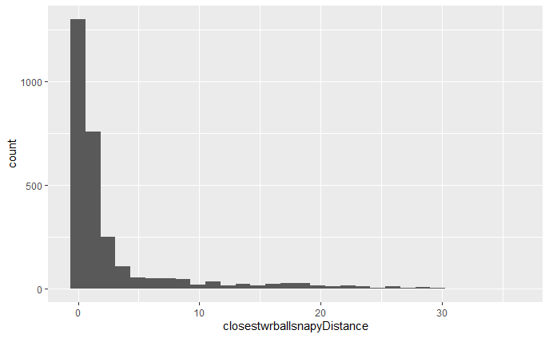

```r
ggplot(closest_wr_ballsnap_df, aes(x=closestwrballsnapyDistance))+
  geom_histogram()
```

#### Plays where a cb was “close” to wr at time of coverage being “done”

Using our coverage_done_frame, we should be able to see how far away cbs were from a wr at the time of coverage being done.

```r
closest_wr_coverage_done_df <- cb_wr_df %>%
  filter(frameId == coverage_done_frame) %>%
  group_by(gameId,playId,nflId) %>%
  slice_min(distance) %>%
  dplyr::select(gameId,playId,nflId,closestwrcoveragedoneId=wrnflId,closestwrcoveragedoneName=wrdisplayName, closestwrcoveragedoneDistance=distance)
```

Let’s again see what our distribution of distances when coverage is done. The average distance from cb to closest wr at coverage done is: **6.36** square yards.

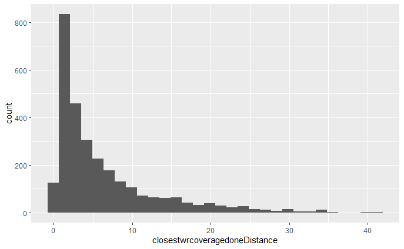

```r
ggplot(closest_wr_coverage_done_df, aes(x=closestwrcoveragedoneDistance))+
  geom_histogram()
```

We’ll join these two data frames to our overall df so we can use these columns

```r
cb_wr_df <- inner_join(cb_wr_df, closest_wr_ballsnap_df, by=c('gameId','playId','nflId'))
cb_wr_df <- inner_join(cb_wr_df, closest_wr_coverage_done_df, by=c('gameId','playId','nflId'))
```

#### Plays where cb and wr have similar “slopes” of their routes or “mirror” each other

One idea is to use regression on cb/wr x and y data to see how closely they mirror each other. We could compare slope direction and magnitude to see which routes are similar? Let’s first test this out with a single play.

```r
ggplotdata = filter(cb_wr_df, playId == 75, frameId <= coverage_done_frame, wrnflId == closestwrcoveragedoneId, wrnflId == closestwrballsnapId, closestwrballsnapyDistance < 3, closestwrcoveragedoneDistance < 10)
```

I’m going to fit linear models to both cb/wr x and y data. Let’s also plot this visually too to make sure it looks right.

```r
lmcb=lm(data=ggplotdata, y~x)
lmcb$coefficients[2]
```

```
         x
-0.2525017
```

```r
lmwr=lm(data=ggplotdata,wry~wrx)
lmwr$coefficients[2]
```

```
       wrx
-0.1557159
```

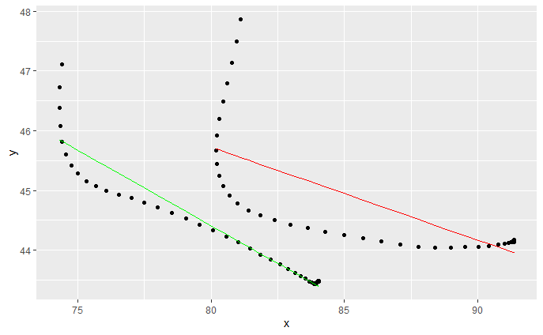

```r
ggplot(data = ggplotdata, aes(x=x,y=y))+
  geom_point()+
  geom_line(aes(x=x,y=lmcb$fitted.values), color='green')+
  geom_point(aes(wrx,wry))+
  geom_line(aes(wrx,y=lmwr$fitted.values), color='red')
```

This looks like it should work, how do we apply this to every play for each cb? I’m going to create another data frame with the following granularity: gameId, playId, cbId, cblm, wrId, wrlm

```r
lmdf <- data.frame(gameId=as.numeric(),playId=as.numeric(),cbId=as.numeric(),cbInt=as.numeric(),cbSlope=as.numeric(),wrId=as.numeric(),wrInt=as.numeric(),wrSlope=as.numeric())
for (game in unique(cb_wr_df$gameId)) {
  plays = filter(cb_wr_df, gameId == game)
  for (play in unique(plays$playId)) {
    cbs = filter(plays, playId == play)
    for (cb in unique(cbs$nflId)) {
      cbdf = filter(cbs, nflId == cb)
      for (wr in unique(cbdf$wrnflId)) {
        wrdf = filter(cbdf, wrnflId == wr)
        cblm = lm(data=wrdf,y~x)
        wrlm = lm(data=wrdf,wry~wrx)
        cbint = cblm$coefficients[1]
        cbslope = cblm$coefficients[2]
        wrint = wrlm$coefficients[1]
        wrslope = wrlm$coefficients[2]
        vector1 = c(game,play,cb,cbint,cbslope,wr,wrint,wrslope)
        lmdf = rbind(lmdf,vector1)
      }
    }
  }
}
colnames(lmdf) <- c('gameId','playId','cbId','cbInt','cbSlope','wrId','wrInt','wrSlope')
head(lmdf)
```

|  | gameId | playId | cbId | cbInt | cbSlope | wrId | wrInt | wrSlope |
| --- | --- | --- | --- | --- | --- | --- | --- | --- |
| 1 | 2018090600 | 75 | 2552689 | -47.839604 | 0.8334335 | 2495454 | 79.739470 | -0.394646687 |
| 2 | 2018090600 | 75 | 2552689 | -47.839604 | 0.8334335 | 2533040 | 37.521810 | -0.020095515 |
| 3 | 2018090600 | 75 | 2555383 | 82.760469 | -0.4692680 | 2495454 | 79.739470 | -0.394646687 |
| 4 | 2018090600 | 75 | 2555383 | 82.760469 | -0.4692680 | 2533040 | 37.521810 | -0.020095515 |
| 5 | 2018090600 | 146 | 2552689 | -7.622624 | 0.4484613 | 2552418 | 87.174036 | -1.276925637 |
| 6 | 2018090600 | 146 | 2552689 | -7.622624 | 0.4484613 | 2557034 | 9.512372 | 0.008062901 |

Quick validation that my logic worked correctly.

```r
length(unique(cb_wr_df$gameId))
```

```
[1] 13
```

```r
length(unique(lmdf$gameId))
```

```
[1] 13
```

```r
length(unique(cb_wr_df$playId))
```

```
[1] 862
```

```r
length(unique(lmdf$playId))
```

```
[1] 862
```

Finally, we need to join to our main data frame which will give us regressions for every cb/wr combo.

```r
cb_wr_df <- inner_join(cb_wr_df, lmdf, by=c('gameId','playId','nflId'='cbId','wrnflId'='wrId'))
```

## Filtering to find coverage frames

We now have a data frame that contains every column we need to identify plays where corner backs were in coverage. Let’s now use these columns to filter our data frame to only frames of x,y data we want.

#### Plays where the cb “lined up” close to the wr at ballsnap

Let’s go back to our distribution of y distances at ball snap.

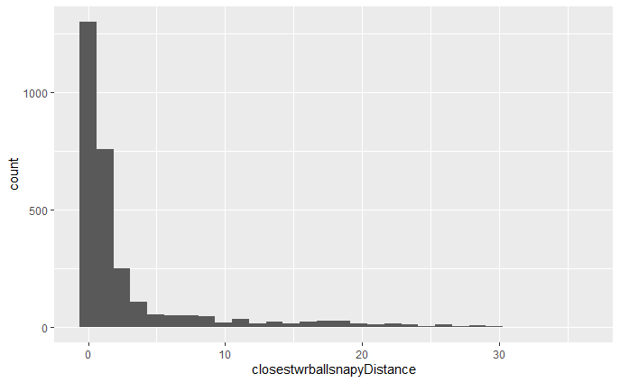

```r
ggplot(closest_wr_ballsnap_df, aes(x=closestwrballsnapyDistance))+
  geom_histogram()
```

Let’s visualize one play where a CB is 2.5 yards away from wr at ball_snap in the y direction.

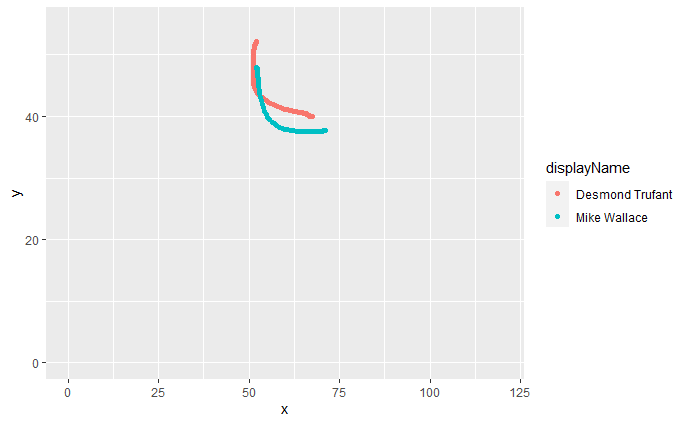

```r
test_data <- filter(cb_wr_df,playId==992, nflId == 2539334 , wrnflId == 2507763)
ggplot(test_data, aes(x=x,y=y))+
  geom_point(aes(color=displayName))+
  geom_point(aes(x=wrx,y=wry, color = wrdisplayName))+
  xlim(0,120)+
  ylim(0,55)
```

Let’s start conservatively and say we only want plays where < 2.5. Let’s also filter out plays where total distance at ball snap is too large (25 yards^2). Cbs can play off the ball coverage but we don’t want too large of distances at ball snap.

```r
cb_wr_df <- filter(cb_wr_df, closestwrballsnapyDistance <= 2.5, closestwrballsnapDistance < 25)
max(cb_wr_df$closestwrballsnapyDistance)
```

```
[1] 2.46
```

#### Plays where cb is in the vicinity of reciever when coverage is over

We can’t assume that a cb being “lined up” over a receiver means they’re covering them. Corner backs could be dropping into zone. We want to look for receivers “in the vicinity” of their receiver when coverage is done.Let’s go back to our distribution of distances when coverage is done.

```r
ggplot(closest_wr_coverage_done_df, aes(x=closestwrcoveragedoneDistance))+
  geom_histogram()
```

[output not shown]

Let’s visualize one play where a CB is “20 units” away from wr at end of coverage.

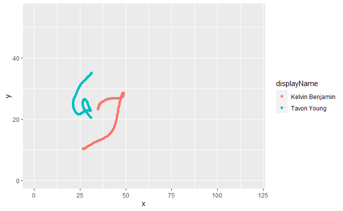

```r
test_data <- filter(cb_wr_df, playId==1869, nflId == 2555378, wrnflId == 2543471)
ggplot(test_data, aes(x=x,y=y))+
  geom_point(aes(color=displayName))+
  geom_point(aes(x=wrx,y=wry, color = wrdisplayName))+
  xlim(0,120)+
  ylim(0,55)
```

Let’s be conservative again, we don’t want to filter out “bad” plays where a cb got beat. Also our last filter on slope of cb/wr routes should filter out more plays.

```r
cb_wr_df <- filter(cb_wr_df, closestwrcoveragedoneDistance <= 20)
max(cb_wr_df$closestwrcoveragedoneDistance)
```

[output not shown]

#### Route slopes for both the cb and wr to be in the same direction/magnitude.

```r
lmdf$slopedirectionMatch <- ifelse(lmdf$cbSlope > 0 & lmdf$wrSlope > 0,1,ifelse(lmdf$cbSlope < 0 & lmdf$wrSlope < 0,1,0))
lmdf$slopemagnitudeMatch <- ifelse(abs(lmdf$cbSlope-lmdf$wrSlope) < 0.5,1,0)
```

Below shows a slope magnitude difference of ~0.7, this doesn’t look like the routes match each other enough. This is why I chose to use 0.5 difference in slope.

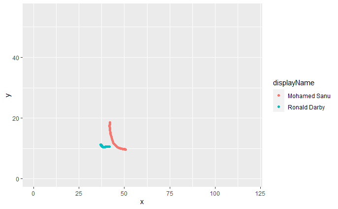

```r
test_data <- filter(cb_wr_df, playId==168, nflId == 2552689, wrnflId == 2533040)
ggplot(test_data, aes(x=x,y=y))+
  geom_point(aes(color=displayName))+
  geom_point(aes(x=wrx,y=wry, color = wrdisplayName))+
  xlim(0,120)+
  ylim(0,55)
```

```r
cb_wr_df <- filter(cb_wr_df, slopemagnitudeMatch != 1 | slopedirectionMatch != 1)
```

#### Additional filters

We also want to apply a couple of last filters:  
* frameId < coverage_done_frame (only want x/y data during “coverage”)  
* wrnflId == closestwrcoveragedoneId, wrnflId == closestwrballsnapId (only want to track x/y data for these receivers)

```r
cb_wr_df <- filter(cb_wr_df, frameId < coverage_done_frame, wrnflId == closestwrcoveragedoneId, wrnflId == closestwrballsnapId)
```

## Preliminary analysis

We finally have a “clean” data frame to play with. Let’s take a peek at the corner backs we’re looking at.

```r
unique(cb_wr_df$displayName)
```

```
 [1] "Jalen Mills"                 "Sidney Jones"
 [3] "Ronald Darby"                "Desmond Trufant"
 [5] "Robert Alford"               "Brian Poole"
 [7] "Ryan Smith"                  "Carlton Davis"
 [9] "Vernon Hargreaves"           "Nate Hairston"
[11] "Briean Boddy-Calhoun"        "Denzel Ward"
[13] "Minkah Fitzpatrick"          "Janoris Jenkins"
[15] "Dre Kirkpatrick"             "Joe Haden"
[17] "Artie Burns"                 "Johnathan Joseph"
[19] "Kevin Johnson"               "Bobby McCain"
[21] "Eli Apple"                   "Phillip Gaines"
[23] "Ken Crawley"                 "Kenny Moore"
[25] "Quincy Wilson"               "Brandon Carr"
[27] "Tavon Young"                 "Kareem Jackson"
[29] "William Jackson"             "Darqueze Dennard"
```

[output cut: 34 more lines]

Let’s start playing around and visualizing a few well known cbs.

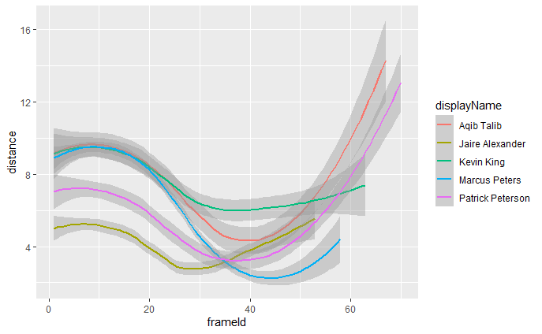

```r
ggplot(data = filter(cb_wr_df, displayName %in% c('Marcus Peters','Patrick Peterson','Kevin King','Jaire Alexander','Aqib Talib')), aes(x = frameId, y = distance))+
  geom_smooth(aes(color = displayName))
```

```r
  #geom_point(aes(color=displayName))
```

This is pretty interesting. Distance from the WRs looks like it goes up initially, drops significantly and than increases again as more frames go by. Jaire Alexander seems to mirror his receivers the cloest in our small group too.

Let’s fit a regression model to our data to quantify distance from receivers over the course of a play. First I’ll plot our data to see if there is anything interesting.

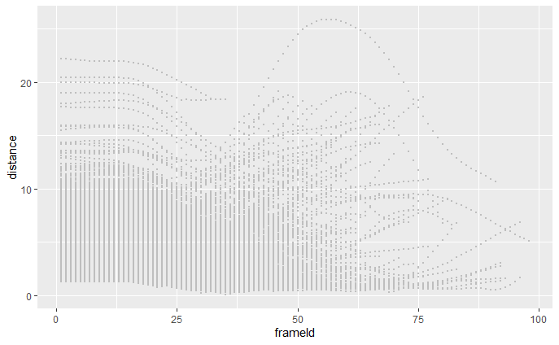

```r
ggplot(cb_wr_df)+
    geom_point(aes(x=frameId,y=distance),color = 'gray', size = 0.1)
```

```r
NA
```

At first glance there doesn’t seem to be much. I’ll try fitting a line to this data using geom_smooth() to see what our pattern looks like.

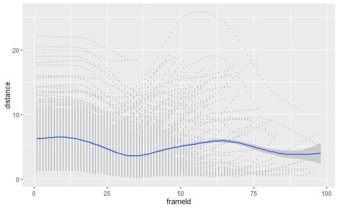

```r
ggplot(cb_wr_df)+
    geom_point(aes(x=frameId,y=distance),color = 'gray', size = 0.1)+
    geom_smooth(aes(x=frameId,y=distance))
```

Looking at the smoothed line, a polynomial fit looks like it could work. Let’s compare to a quadratic fit to see the difference.

```r
mq <- lm(data=cb_wr_df,distance~poly(frameId,2,raw=TRUE))
mp <- lm(data=cb_wr_df,distance~poly(frameId,5,raw=TRUE))
summary(mq)
```

```
Call:
lm(formula = distance ~ poly(frameId, 2, raw = TRUE), data = cb_wr_df)

Residuals:
    Min      1Q  Median      3Q     Max
-6.5907 -2.5410 -0.5318  1.8500 21.5624

Coefficients:
                                Estimate Std. Error t value Pr(>|t|)
(Intercept)                    7.202e+00  4.917e-02  146.47   <2e-16 ***
poly(frameId, 2, raw = TRUE)1 -1.313e-01  3.432e-03  -38.27   <2e-16 ***
poly(frameId, 2, raw = TRUE)2  1.426e-03  5.204e-05   27.40   <2e-16 ***
---
Signif. codes:  0 ‘***’ 0.001 ‘**’ 0.01 ‘*’ 0.05 ‘.’ 0.1 ‘ ’ 1

Residual standard error: 3.26 on 28174 degrees of freedom
Multiple R-squared:  0.06726,   Adjusted R-squared:  0.06719
F-statistic:  1016 on 2 and 28174 DF,  p-value: < 2.2e-16
```

```r
summary(mp)
```

```
Call:
lm(formula = distance ~ poly(frameId, 5, raw = TRUE), data = cb_wr_df)

Residuals:
    Min      1Q  Median      3Q     Max
-5.5181 -2.4429 -0.4864  1.8258 20.4620

Coefficients:
                                Estimate Std. Error t value Pr(>|t|)
(Intercept)                    5.390e+00  9.642e-02   55.90   <2e-16 ***
poly(frameId, 5, raw = TRUE)1  4.123e-01  2.368e-02   17.41   <2e-16 ***
poly(frameId, 5, raw = TRUE)2 -3.853e-02  1.793e-03  -21.48   <2e-16 ***
poly(frameId, 5, raw = TRUE)3  1.116e-03  5.555e-05   20.10   <2e-16 ***
poly(frameId, 5, raw = TRUE)4 -1.287e-05  7.396e-07  -17.40   <2e-16 ***
poly(frameId, 5, raw = TRUE)5  5.141e-08  3.500e-09   14.69   <2e-16 ***
---
Signif. codes:  0 ‘***’ 0.001 ‘**’ 0.01 ‘*’ 0.05 ‘.’ 0.1 ‘ ’ 1

Residual standard error: 3.213 on 28171 degrees of freedom
Multiple R-squared:  0.09386,   Adjusted R-squared:  0.0937
F-statistic: 583.6 on 5 and 28171 DF,  p-value: < 2.2e-16
```

Obviously the fit containing higher order terms is going to fit the data the closest. The polynomial fit explains about 3% more of the variation in our data compared to the quadratic fit. I’ll visualize the fit below as well.

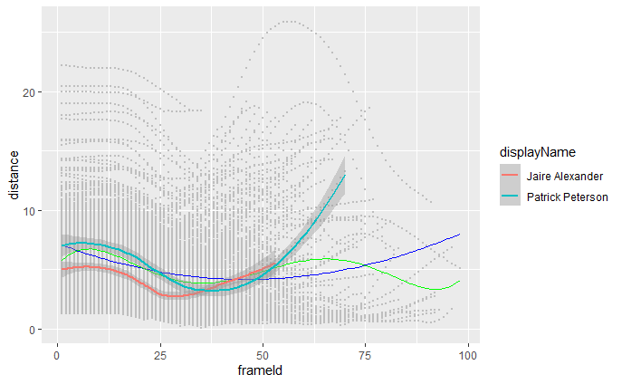

```r
ggplot(data=cb_wr_df)+
  geom_point(aes(x=frameId,y=distance),color = 'gray', size = 0.1)+
  geom_line(aes(x=frameId,y=mq$fitted.values), color = 'blue')+
  geom_line(aes(x=frameId,y=mp$fitted.values), color = 'green')+
  geom_smooth(data=filter(cb_wr_df,displayName %in% c('Patrick Peterson','Jaire Alexander')),aes(x=frameId,y=distance, color=displayName))
```

It’s curious too that towards the end of some of these longer plays, separation drops significantly again. Could this be due to longer throws where a corner back is actually catching back up to their receiver?

General thoughts:  
Which cbs have the least amount of separation?  
Is separation earlier in a play more predictive of pass outcomes?

**To be continued…**